# Sentiment Analysis using tidytext

## Sentiment Analysis using TidyVerse

The tidytext package provides access to several sentiment lexicons. Three general-purpose lexicons are:

- AFINN from Finn Årup Nielsen,
- bing from Bing Liu and collaborators,
- nrc from Saif Mohammad and Peter Turney.

All three of these lexicons are based on unigrams, i.e., single words. These lexicons contain many English words and the words are assigned scores for positive/negative sentiment, and also possibly emotions like joy, anger, sadness, and so forth. There are also some domain-specific sentiment lexicons available, constructed to be used with text from a specific content area, such as fianance (tm.plugin.webmining) or social medida (vader).

**Caveats**

- lexicon-based on unigrams only do not take into account qualifiers before a word, such as in “no good” or “not true”
- the size of text chunk used to add up unigram sentiment scores can effect the analysis. A text the size of many paragraphs can often have positive and negative sentiment averaged out to about zero, while sentence-sized or paragraph-sized text often works better

### Load common libraries

```r
# twitter library
library(rtweet)

# plotting and pipes - tidyverse
library(ggplot2)
library(dplyr, warn.conflicts = FALSE)
options(dplyr.summarise.inform = FALSE) # Suppress summarise info

# text mining library
suppressPackageStartupMessages(library(tidyverse)) # suppress startup message

library(tidytext)

# stemming libary
library(SnowballC)

# lemmatization
library(textstem)
```

### Read and transform data

- filter out retweets
- screen name should be a factor
- add “doc_id” which corresponds to the row number for the record
- add “text_len” to capture the length of each text

```
## 'data.frame':    4765 obs. of  2 variables:
##  $ screen_name: chr  "JoeBiden" "JoeBiden" "JoeBiden" "JoeBiden" ...
##  $ text       : chr  "I couldn’t be more excited to have my friend @BarackObama hitting the campaign trail. Tune in for his first dri"| __truncated__ "It’s time we replace Secretary Betsy DeVos with an actual public school educator — one who values our public sc"| __truncated__ "Tune in as @Barac…
```

|  | doc_id | screen_name | text | text_len |
| --- | --- | --- | --- | --- |
| 1 | doc1 | JoeBiden | I couldn’t be more excited to have my friend @BarackObama hitting the campaign trail. Tune in for his first drive-in rally live from Philadelphia. https://t.co/NJyChqivOt | 170 |
| 2 | doc2 | JoeBiden | It’s time we replace Secretary Betsy DeVos with an actual public school educator — one who values our public schools and is capable of guiding all of our schools through this pandemic.\n\nVote: https:… | 239 |
| 3 | doc3 | JoeBiden | Tune in as @BarackObama sits down with community leaders in Philadelphia to talk about what’s at stake in this election. https://t.co/Xzmy0Cs3sw | 144 |

|  | doc_id | screen_name | text | text_len |
| --- | --- | --- | --- | --- |
| 4763 | doc4763 | realDonaldTrump | Cases up because of BIG Testing! Much of our Country is doing very well. Open the Schools! | 90 |
| 4764 | doc4764 | realDonaldTrump | FAKE NEWS IS THE ENEMY OF THE PEOPLE! | 37 |
| 4765 | doc4765 | realDonaldTrump | With the exception of New York &amp; a few other locations, we’ve done MUCH better than most other Countries in dealing with the China Virus. Many of these countries are now having a major second wave… | 287 |

### tidying and text cleaning

Tidy so that the text is in a tidy format with one word per row and also perform text preprocessing

- remove URLs, numbers, white space
- stemming or lemmatization. For sentiment, lemmatization may be better as stemming may result in non-words
- unnest_tokens() for creating a tidy format automatically converts to lowercase, so no need to normalize
- tidytext also removes punctuation automatically.

| doc_id | screen_name | text_len | word |
| --- | --- | --- | --- |
| doc13 | JoeBiden | 130 | i’ve |
| doc13 | JoeBiden | 130 | believe |
| doc13 | JoeBiden | 130 | we’re |
| doc13 | JoeBiden | 130 | we’re |
| doc13 | JoeBiden | 130 | america |
| doc13 | JoeBiden | 130 | there’s |
| doc13 | JoeBiden | 130 | single |
| doc13 | JoeBiden | 130 | overcome |
| doc16 | JoeBiden | 81 | listen |
| doc16 | JoeBiden | 81 | scientist |

[output cut: 9990 more lines]

### Summary text length

```
##           screen_name      text_len
##  JoeBiden       :8597   Min.   : 10.0
##  realDonaldTrump:5031   1st Qu.:169.0
##                         Median :228.0
##                         Mean   :210.8
##                         3rd Qu.:270.0
##                         Max.   :284.0
```

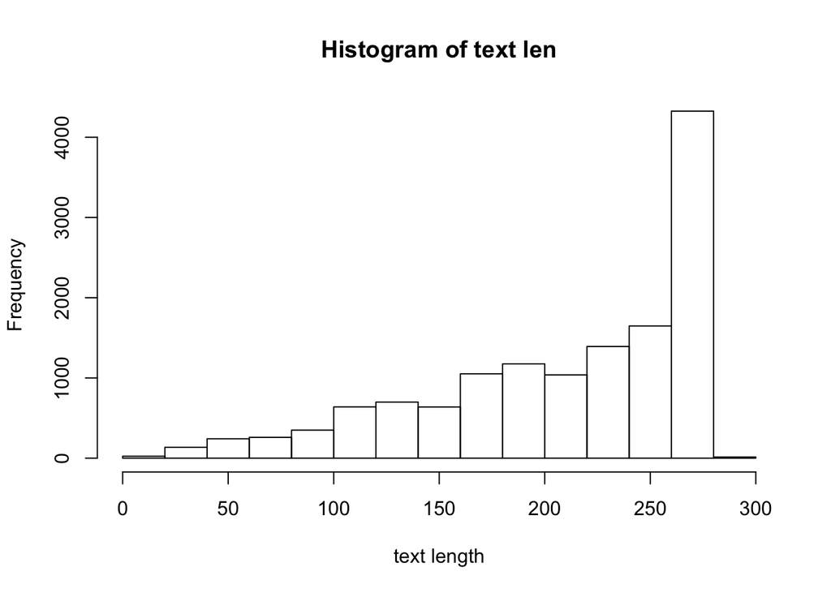

### Summary by user

```
##           screen_name      text_len
##  JoeBiden       :8597   Min.   : 12
##  realDonaldTrump:   0   1st Qu.:172
##                         Median :229
##                         Mean   :212
##                         3rd Qu.:267
##                         Max.   :284
```

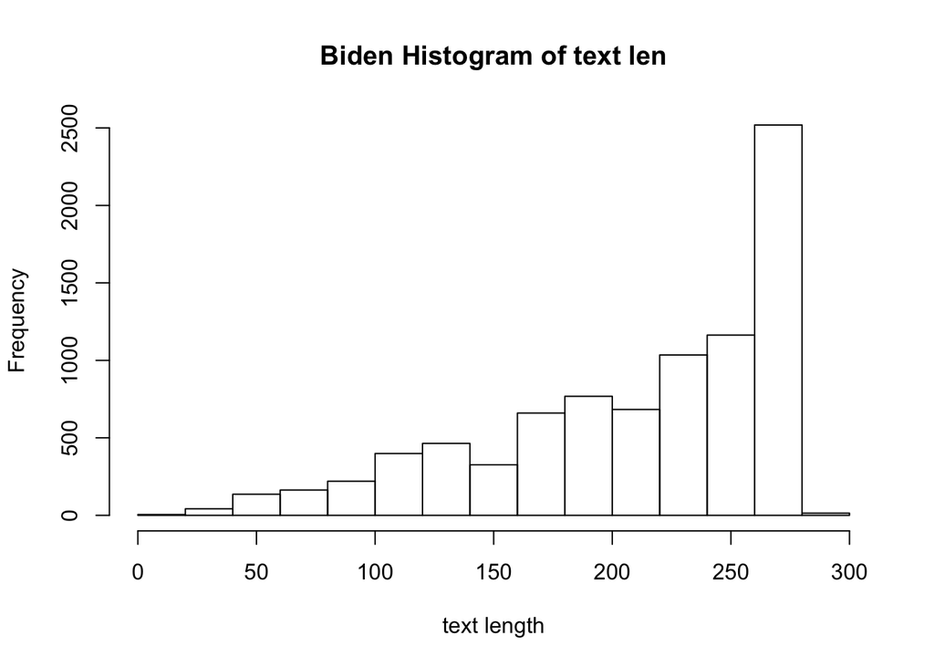

```
##           screen_name      text_len
##  JoeBiden       :   0   Min.   : 10.0
##  realDonaldTrump:5031   1st Qu.:161.0
##                         Median :227.0
##                         Mean   :208.8
##                         3rd Qu.:274.0
##                         Max.   :280.0
```

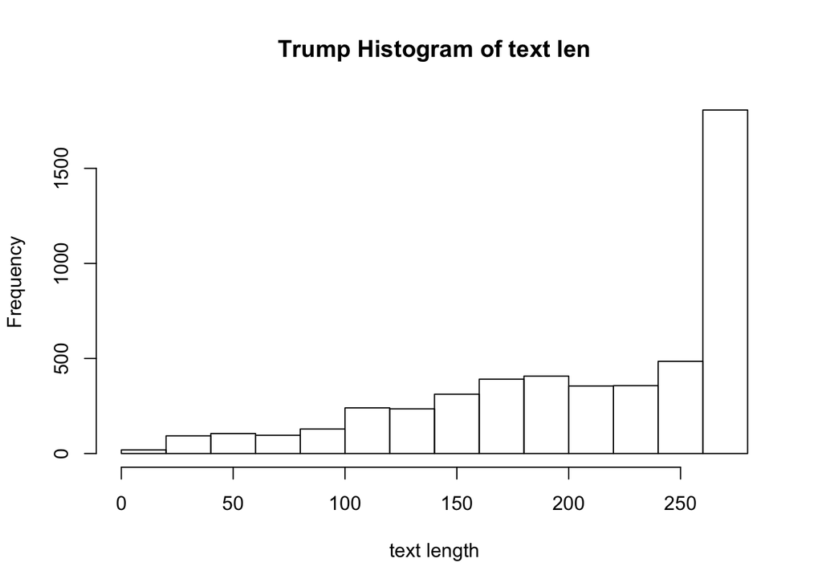

- We see that the length of posts by Trump and Biden are close though Biden’s is a bit longer
- Biden’s posts on average have a length of 212 with some longer text with a max length of 284
- Trump’s posts on average have a length of 208 with some longer text with a max length of 280

### Tweets by User

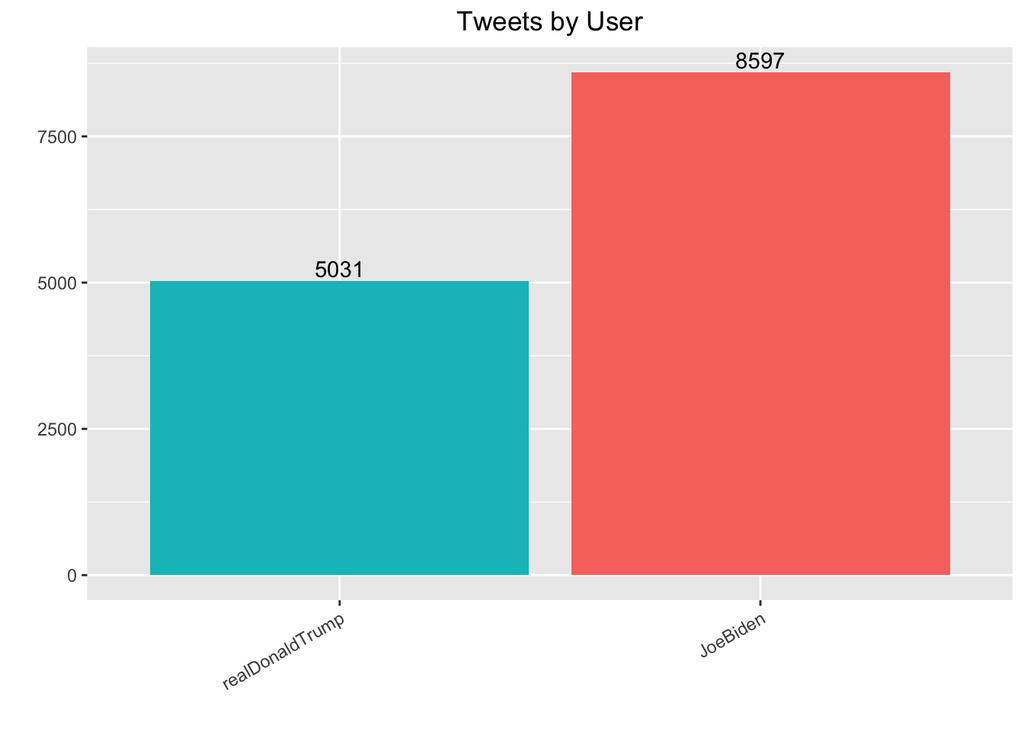

In this dataset, we see that Biden actually has more original tweets (eg: dataframe was filtered to exclude retweets)

### Sentiment Analysis.

With data in a tidy format, sentiment analysis can be done as an inner join. First, let’s take a look at the 3 sentiment lexicons. Note: need to first download: get_sentiments(“nrc”)

### Word Sentiment Categorization using nrc

```r
get_sentiments("nrc") %>%
  group_by(sentiment) %>%
  summarise(n=n())  %>%
  arrange(-n)
```

| sentiment | n |
| --- | --- |
| negative | 3324 |
| positive | 2312 |
| fear | 1476 |
| anger | 1247 |
| trust | 1231 |
| sadness | 1191 |
| disgust | 1058 |
| anticipation | 839 |
| joy | 689 |
| surprise | 534 |

- The nrc lexicon categorizes words in a binary fashion (“yes”/“no”) into categories of positive, negative, anger, anticipation, disgust, fear, joy, sadness, surprise, and trust
- 10 scale sentiment groupings, including positive and negative

### Word Sentiment Categorization using bing

```r
get_sentiments("bing") %>%
  group_by(sentiment) %>%
  summarise(n=n())  %>%
  arrange(-n)
```

| sentiment | n |
| --- | --- |
| negative | 4781 |
| positive | 2005 |

- The bing lexicon categorizes words in a binary fashion into positive and negative categories
- 2 scales (positive and negative)

### Word Sentiment Categorization using afinn

```r
get_sentiments("afinn") %>%
  group_by(value) %>%
  summarise(n=n())  %>%
  arrange(-n)
```

| value | n |
| --- | --- |
| -2 | 966 |
| 2 | 448 |
| -1 | 309 |
| -3 | 264 |
| 1 | 208 |
| 3 | 172 |
| 4 | 45 |
| -4 | 43 |
| -5 | 16 |
| 5 | 5 |

[output cut: 1 more lines]

- The AFINN lexicon assigns words with a score that runs between -5 and 5, with negative scores indicating negative sentiment and positive scores indicating positive sentiment.
- numeric sale from -5 to + 5

### Average sentiment scores by user using afinn

Frequency of positive and negative words and which user were the most positive or negative overall?

| screen_name | word | n |
| --- | --- | --- |
| JoeBiden | president | 220 |
| JoeBiden | trump | 185 |
| JoeBiden | donald | 162 |
| JoeBiden | american | 116 |
| JoeBiden | nation | 103 |
| JoeBiden | people | 92 |
| realDonaldTrump | biden | 83 |
| JoeBiden | america | 79 |
| JoeBiden | country | 76 |
| JoeBiden | time | 75 |

[output cut: 3706 more lines]

| screen_name | value |
| --- | --- |
| JoeBiden | 0.06397953 |
| realDonaldTrump | -0.31585518 |

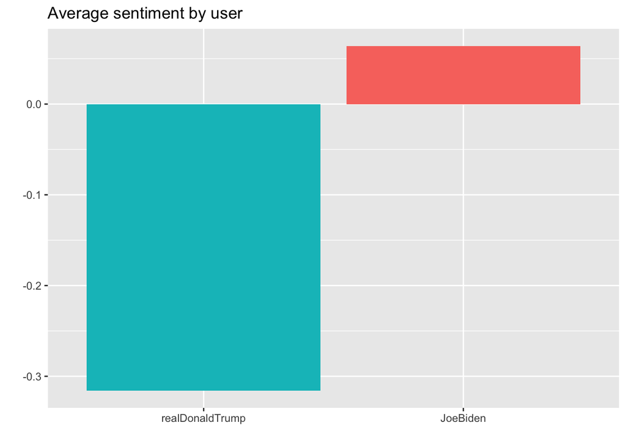

We can see that Trump tweets on average are more negative than Biden

### Analysis by word using afinn

It’s worth looking deeper to understand why some Users ended up more positive or negative than others. For that, we can examine the total positive and negative contributions of each word.

| word | occurences | contribution |
| --- | --- | --- |
| abandon | 1 | -2 |
| ability | 1 | 2 |
| absentee | 1 | -1 |
| abuse | 1 | -3 |
| accept | 2 | 2 |
| accomplish | 1 | 2 |
| adequate | 1 | 1 |
| admire | 1 | 3 |
| admit | 2 | -2 |
| adopt | 1 | 1 |

[output cut: 439 more lines]

| word | occurences | contribution |
| --- | --- | --- |
| fun | 2 | 8 |
| hell | 2 | -8 |
| win | 2 | 8 |
| angry | 2 | -6 |
| bad | 2 | -6 |
| betray | 2 | -6 |
| breakthrough | 2 | 6 |
| celebrate | 2 | 6 |
| crime | 2 | -6 |
| desperate | 2 | -6 |

[output cut: 17 more lines]

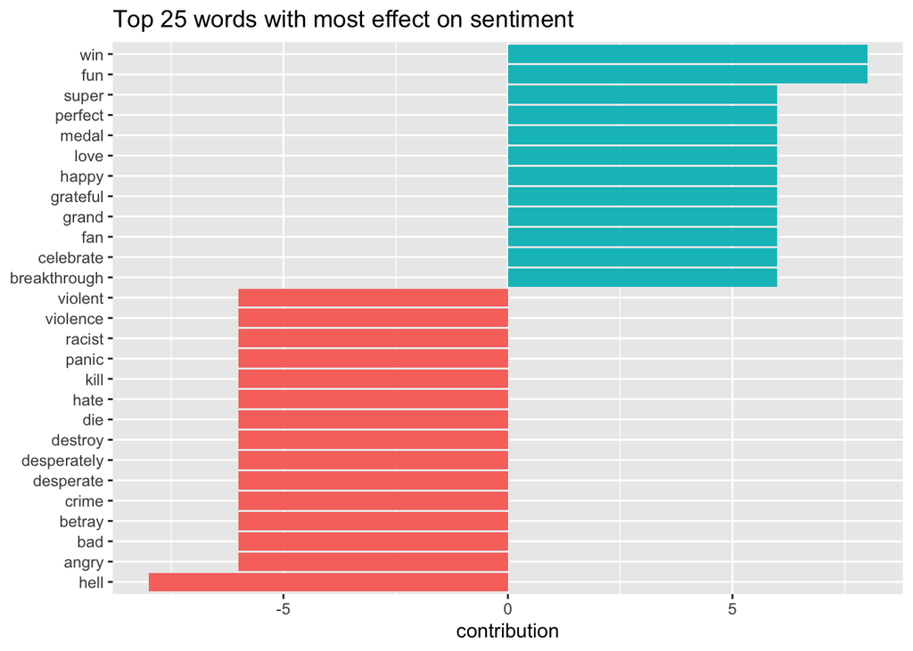

- Here we see the list of words which contribute the most to each affin sentiment score
- The plot shows the top 25 words sorted by the highest contribution
- These words seem to make sense

### Which words contributed the most to sentiment by user?

| screen_name | word | n | value | avg_contribution |
| --- | --- | --- | --- | --- |
| JoeBiden | crisis | 62 | -3 | -0.078680203 |
| realDonaldTrump | win | 38 | 4 | 0.064297800 |
| JoeBiden | care | 54 | 2 | 0.045685279 |
| realDonaldTrump | fake | 34 | -3 | -0.043147208 |
| JoeBiden | violence | 25 | -3 | -0.031725888 |
| realDonaldTrump | bad | 22 | -3 | -0.027918782 |
| JoeBiden | hate | 21 | -3 | -0.026649746 |
| JoeBiden | bad | 19 | -3 | -0.024111675 |
| JoeBiden | justice | 26 | 2 | 0.021996616 |
| JoeBiden | strong | 26 | 2 | 0.021996616 |

[output cut: 40 more lines]

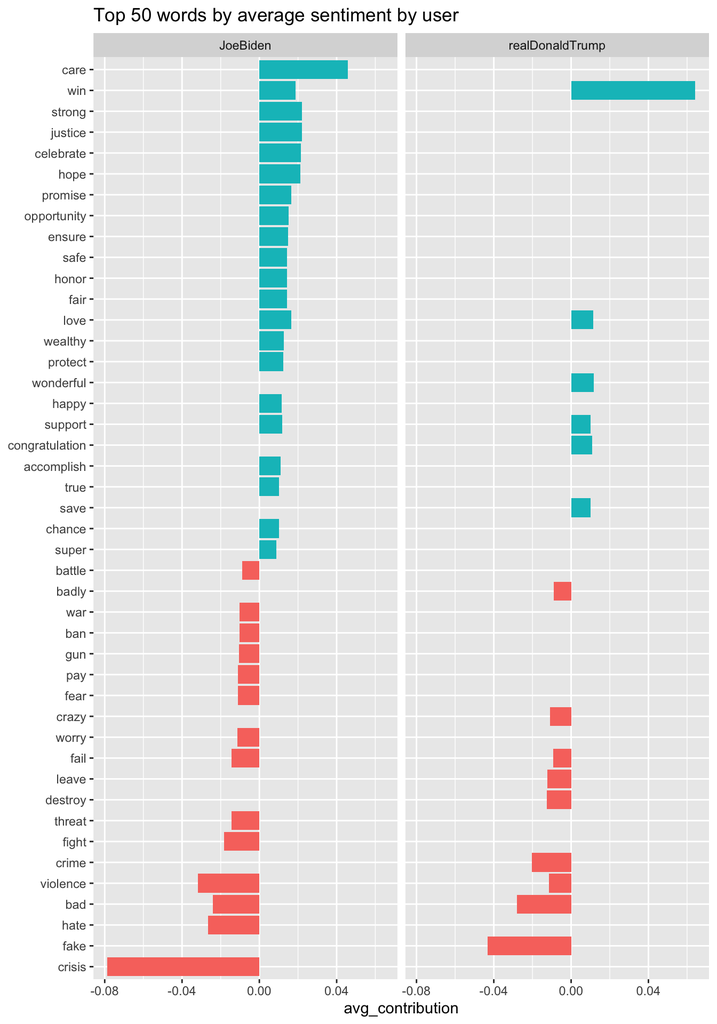

### Find most positive and negative individual messages by user

As a simple measure to reduce the role of randomness, we filtered out messages that had fewer than five words that contributed to sentiment.

| screen_name | doc_id | sentiment | words |
| --- | --- | --- | --- |
| JoeBiden | doc1034 | 0.0000000 | 9 |
| JoeBiden | doc1041 | -0.8000000 | 5 |
| JoeBiden | doc1153 | -0.8000000 | 5 |
| JoeBiden | doc1176 | -1.8333333 | 6 |
| JoeBiden | doc1189 | 0.2000000 | 5 |
| JoeBiden | doc1245 | 0.8000000 | 5 |
| JoeBiden | doc1246 | -1.0000000 | 5 |
| JoeBiden | doc1249 | 0.2000000 | 5 |
| JoeBiden | doc1272 | -0.2000000 | 5 |
| JoeBiden | doc1286 | 1.2000000 | 5 |

[output cut: 131 more lines]

### What were the most positive messages in the whole dataset?

| screen_name | doc_id | sentiment | words |
| --- | --- | --- | --- |
| JoeBiden | doc2554 | 2.8000000 | 5 |
| realDonaldTrump | doc4666 | 2.6000000 | 5 |
| realDonaldTrump | doc4623 | 2.4000000 | 5 |
| JoeBiden | doc2915 | 2.2000000 | 5 |
| JoeBiden | doc290 | 2.1666667 | 6 |
| realDonaldTrump | doc3925 | 2.1111111 | 9 |
| JoeBiden | doc1444 | 2.0000000 | 6 |
| JoeBiden | doc2018 | 2.0000000 | 5 |
| JoeBiden | doc427 | 2.0000000 | 5 |
| JoeBiden | doc2894 | 1.8888889 | 9 |

[output cut: 131 more lines]

- the most positive sentiment by Biden is doc2554
- the most positive sentiment by Trump is doc4666
- Let’s see the message details of theses tweets.

```
## [1] "Most Positive tweet by Biden"
```

```
## Happy Lunar New Year to all those celebrating throughout the country. I'm grateful for the contributions that the AAPI community has made to enrich America's diversity. I hope the Year of the Rat brings good fortune, health, and happiness to all.
```

```
## [1] "Most Positive tweet by Trump"
```

```
## Congratulations to future Republican Star Marjorie Taylor Greene on a big Congressional primary win in Georgia against a very tough and smart opponent. Marjorie is strong on everything and never gives up - a real WINNER!
```

### How about the most negative message?

| screen_name | doc_id | sentiment | words |
| --- | --- | --- | --- |
| JoeBiden | doc2504 | -2.5000000 | 6 |
| JoeBiden | doc842 | -2.4000000 | 5 |
| JoeBiden | doc1362 | -2.2000000 | 5 |
| realDonaldTrump | doc4252 | -2.2000000 | 5 |
| realDonaldTrump | doc4667 | -2.2000000 | 5 |
| realDonaldTrump | doc3219 | -2.1666667 | 6 |
| JoeBiden | doc1944 | -2.0000000 | 5 |
| realDonaldTrump | doc4005 | -2.0000000 | 6 |
| realDonaldTrump | doc4260 | -2.0000000 | 5 |
| JoeBiden | doc1176 | -1.8333333 | 6 |

[output cut: 131 more lines]

```
## [1] "Most Negative tweet by Biden"
```

```
## We are in the midst of a crisis with the coronavirus. We need to lead the way with science — not Donald Trump’s record of hysteria, xenophobia, and fear-mongering. He is the worst possible person to lead our country through a global health emergency.
```

```
## [1] "Most Negative tweet by Trump"
```

```
## ....His problem is interesting. He must always be weak on CRIME because of the Bernie Sanders Radical Left voter. If he loses them, like Crooked Hillary did, he is “toast”, and many will vote for me because of TRADE (Bernie was good on trade). Joe MUST always be weak on crime!
```

- the most negative sentiment by Biden is doc2504
- the most negative sentiment by Trump is doc4252